# Chapter 4 Initial diversity analyses

We use [hilldiv3](https://alberdilab.github.io/hilldiv3/) to describe diversity in the selected panel. Neutral Hill numbers use representative relative abundances; phylogenetic Hill numbers also use the pruned representative tree. We evaluate diversity orders $q=0$ (all detected units receive full weight), $q=1$ (abundance-weighted diversity), and $q=2$ (common units weighted more strongly). For neutral diversity, $q=0$ is the count of detected representatives. Functional diversity awaits a matched trait or gene-function table.

## 4.1 Within-sample diversity

`hilldiv()` calculates one diversity type per call. The tree and pooled reference depth are supplied only for phylogenetic diversity.

```r
alpha_neutral <- hilldiv3::hilldiv(
  overview_abundance, q = c(0, 1, 2), type = "neutral"
)
alpha_phylogenetic <- hilldiv3::hilldiv(
  overview_abundance, q = c(0, 1, 2), tree = genome_tree,
  type = "phylogenetic", reference = "pool"
)
```

For the plots and table below, the results are joined to habitat labels.

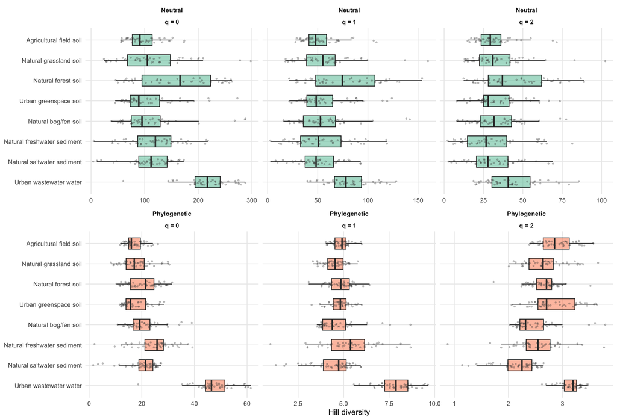

```r
ggplot2::ggplot(alpha_diversity,
                ggplot2::aes(x = value, y = habitat, fill = type)) +
  ggplot2::geom_boxplot(outlier.shape = NA, width = 0.55, alpha = 0.55,
                        colour = "grey20") +
  ggplot2::geom_jitter(height = 0.13, width = 0, alpha = 0.28,
                       size = 0.65, colour = "grey25") +
  ggplot2::scale_fill_manual(values = type_colours, guide = "none") +
  ggplot2::facet_wrap(ggplot2::vars(type, order), ncol = 3,
                      scales = "free_x") +
  ggplot2::labs(x = "Hill diversity", y = NULL) +
  ggplot2::theme_minimal(base_size = 10) +
  ggplot2::theme(panel.grid.minor = ggplot2::element_blank(),
                 strip.text = ggplot2::element_text(face = "bold"))
```

*Hill numbers for 45 samples in each habitat class. Boxes show medians and interquartile ranges; points are individual samples. Horizontal scales differ by panel.*

```r
q1 <- alpha_diversity[alpha_diversity$q == 1, ]
q1_summary <- aggregate(
  value ~ habitat + type, data = q1,
  FUN = function(x) sprintf("%.1f [%.1f–%.1f]",
                            median(x), unname(quantile(x, 0.25)),
                            unname(quantile(x, 0.75)))
)
q1_neutral <- q1_summary[q1_summary$type == "Neutral", c("habitat", "value")]
q1_phylo <- q1_summary[q1_summary$type == "Phylogenetic", c("habitat", "value")]
names(q1_neutral)[2] <- "Neutral q = 1"
names(q1_phylo)[2] <- "Phylogenetic q = 1"
q1_table <- merge(q1_neutral, q1_phylo, by = "habitat", sort = FALSE)
q1_table <- q1_table[match(habitat_levels, q1_table$habitat), ]
names(q1_table)[1] <- "Habitat"
rownames(q1_table) <- NULL
knitr::kable(q1_table, row.names = FALSE)
```

| Habitat | Neutral q = 1 | Phylogenetic q = 1 |
| --- | --- | --- |
| Agricultural field soil | 47.8 [41.2–58.8] | 4.9 [4.5–5.1] |
| Natural grassland soil | 55.1 [38.9–67.3] | 4.5 [4.1–5.0] |
| Natural forest soil | 74.5 [47.9–107.0] | 4.8 [4.3–5.3] |
| Urban greenspace soil | 48.4 [39.1–64.9] | 4.8 [4.4–5.1] |
| Natural bog/fen soil | 52.7 [35.6–67.6] | 4.4 [3.8–5.1] |
| Natural freshwater sediment | 50.6 [32.8–73.2] | 5.4 [4.3–6.2] |
| Natural saltwater sediment | 48.3 [37.4–65.7] | 4.7 [3.9–5.1] |
| Urban wastewater water | 78.0 [66.6–93.6] | 7.9 [7.3–8.5] |

*Median [interquartile range] of $q=1$ diversity by habitat.*

At $q=1$, median neutral diversity ranges from 47.8 in Agricultural field soil to 78.0 in Urban wastewater water.

The phylogenetic values use hilldiv3’s common pooled reference tree depth, so samples are evaluated on the same scale. Their numerical values should be compared within the phylogenetic panels, rather than interpreted as counts of MAGs. Neutral $q=0$ is the number of representatives with a positive reported abundance; it is sensitive to very small values in the source profiles.

## 4.2 Diversity profiles across orders

`hillprof()` extends the three selected orders to a finer sweep. To keep the comparison readable, each habitat profile below is the mean of its 45 sample abundance vectors. These are descriptive pooled profiles; their $q=0$ values count representatives detected in any of those samples.

```r
profile_neutral <- hilldiv3::hillprof(
  habitat_profiles, q = seq(0, 2, by = 0.25), type = "neutral"
)
profile_phylogenetic <- hilldiv3::hillprof(
  habitat_profiles, q = seq(0, 2, by = 0.25), tree = genome_tree,
  type = "phylogenetic", reference = "pool"
)
```

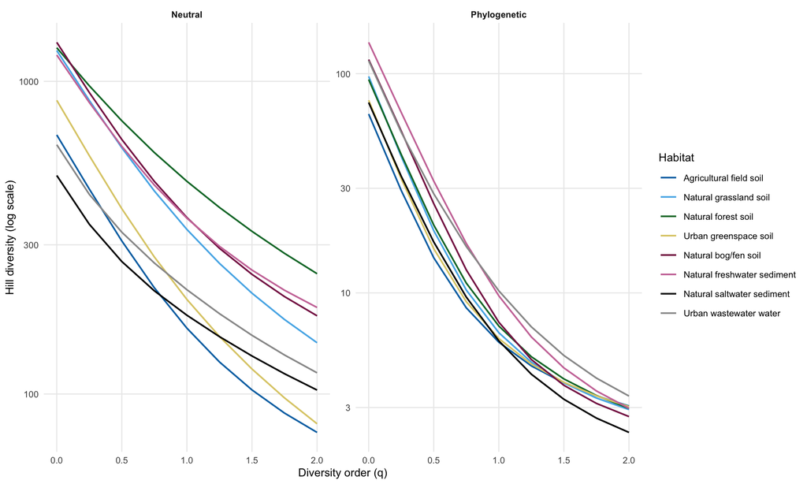

```r
ggplot2::ggplot(profiles,
                ggplot2::aes(x = q, y = value, colour = sample)) +
  ggplot2::geom_line(linewidth = 0.7) +
  ggplot2::scale_colour_manual(values = habitat_colours) +
  ggplot2::scale_y_log10() +
  ggplot2::facet_wrap(~ type, scales = "free_y") +
  ggplot2::labs(x = "Diversity order (q)", y = "Hill diversity (log scale)",
                colour = "Habitat") +
  ggplot2::theme_minimal(base_size = 10) +
  ggplot2::theme(panel.grid.minor = ggplot2::element_blank(),
                 strip.text = ggplot2::element_text(face = "bold"))
```

*Diversity profiles of the mean abundance vector in each habitat. The two panels use separate vertical scales; values should be compared within a panel.*

The neutral ranking changes with order: bog/fen soil has the highest pooled richness at $q=0$, while forest soil has the highest diversity at $q=1$ and $q=2$. This illustrates why a single diversity order does not capture every aspect of a profile.

## 4.3 Partitioning across habitats

The next calculation partitions diversity across individual samples, habitat classes, and the complete panel. At each step, hilldiv3 reports a beta factor: the effective number of distinct units added at that scale. The two beta factors multiply to give the total gamma-to-alpha ratio. Each sample has equal weight; the design has 45 samples in every habitat class.

`hillpart()` uses the habitat metadata to partition diversity across the sample-to-habitat and habitat-to-panel scales.

```r
partition_neutral <- hilldiv3::hillpart(
  overview_abundance, q = c(0, 1, 2),
  hierarchy = ~ habitat_class, metadata = habitat_metadata,
  type = "neutral"
)
partition_phylogenetic <- hilldiv3::hillpart(
  overview_abundance, q = c(0, 1, 2), tree = genome_tree,
  hierarchy = ~ habitat_class, metadata = habitat_metadata,
  type = "phylogenetic"
)
```

```r
partition_neutral <- plain_hill_result(partition_neutral)
partition_phylogenetic <- plain_hill_result(partition_phylogenetic)
partition_neutral$type <- "Neutral"
partition_phylogenetic$type <- "Phylogenetic"
partition <- rbind(partition_neutral, partition_phylogenetic)
stopifnot(all(is.finite(partition$diversity)),
          all(is.finite(partition$beta[partition$scale != "sample"])))

within <- partition[partition$scale == "habitat_class",
                    c("type", "q", "beta")]
between <- partition[partition$scale == "total",
                     c("type", "q", "beta", "diversity")]
names(within)[3] <- "Within habitats"
names(between)[3:4] <- c("Between habitats", "Gamma diversity")
partition_table <- merge(within, between, by = c("type", "q"), sort = FALSE)
partition_table <- partition_table[order(match(partition_table$type,
                                                c("Neutral", "Phylogenetic")),
                                          partition_table$q), ]
knitr::kable(partition_table, digits = 2)
```

| type | q | Within habitats | Between habitats | Gamma diversity |
| --- | --- | --- | --- | --- |
| Neutral | 0 | 7.50 | 3.66 | 3552.00 |
| Neutral | 1 | 5.04 | 3.33 | 893.78 |
| Neutral | 2 | 4.80 | 2.76 | 334.78 |
| Phylogenetic | 0 | 4.17 | 3.29 | 611.03 |
| Phylogenetic | 1 | 1.46 | 1.56 | 21.51 |
| Phylogenetic | 2 | 1.12 | 1.12 | 6.19 |

*Hierarchical Hill-number partition. Beta factors describe sample-to-habitat and habitat-to-panel turnover; gamma is diversity in the full panel.*

At $q=1$, neutral beta diversity is 5.04 from samples to habitats and 3.33 from habitats to the full panel. The corresponding phylogenetic factors are 1.46 and 1.56.

These are descriptive comparisons of a geographically selected panel. Habitat and collection year are not independently balanced, so these summaries do not by themselves establish habitat effects. Relative abundances also cannot support read-count rarefaction or sampling-depth uncertainty estimates.